# Diana Ruiz Moctezuma

## Tarea clasificación supervisada

1. Seleccionar un conjunto de datos para una tarea de clasificación supervisada que sea de tu interés, disponible en alguno de los repositorios mencionados en la clase anterior (puede ser el mismo utilizado en la tarea previa).
2. Elegir también un método de validación de los vistos en clase.
3. Realizar el preprocesamiento del conjunto de datos y ejecuta todos los algoritmos estudiados en clase.
4. Reportar la matriz de confusión de cada algoritmo
5. Reportar una tabla comparativa que incluya todas las medidas de desempeño correspondientes.
6. Graficar las medidas de desempeño reportadas en gráfico de barras

## Objetivo

El objetivo de este modelo fue predecir si un estudiante aprobaría o no la asignatura de matemáticas a partir de diferentes características relacionadas a asu contexto académico y personal. El problema se formuló con una clasificación binaria, donde:

- Clase 1: El estudiante aprueba matemátocas
- Clase 0: El estudiante no aprueba matemáticas

La **variable objetivo** no estaba presente directamente en el dataset original. El conjunto de datos incluía únicamente la variable math score, que representa la calificación numérica obtenida por cada estudiante en el examen de matemáticas.

Para formular el problema como una clasificación binaria, se construyó una nueva variable objetivo que indica si el estudiante aprueba o no la asignatura. Esta variable se generó a partir del valor de math score utilizando un umbral de aprobación.

De esta manera se definieron las clases:

1 → Aprueba matemáticas

0 → No aprueba matemáticas

Una vez creada esta variable, la columna original math score fue eliminada del conjunto de características, con el fin de evitar que el modelo utilizara directamente la información que define la variable objetivo, lo cual provocaría data leakage.

```python
#pip install seaborn
```

```python
# Librerias básicas
import pandas as pd
import numpy as np
import matplotlib.pyplot as plt
import seaborn as sns

# Formato
from IPython.display import display,Markdown

# Validación
from sklearn.model_selection import train_test_split

# Modelos de clasificación
from sklearn.neighbors import KNeighborsClassifier
from sklearn.naive_bayes import GaussianNB
from sklearn.linear_model import LogisticRegression
from sklearn.tree import DecisionTreeClassifier
from sklearn.svm import SVC
from sklearn.ensemble import RandomForestClassifier
from sklearn.neural_network import MLPClassifier
from sklearn.naive_bayes import GaussianNB

# Pipeline y normalizacion
from sklearn.preprocessing import StandardScaler
from sklearn.pipeline import Pipeline

# Feature selection librerias
from utils import calculate_imbalance_ratio

# SMOTE
from SMOTE import plot_class_distribution, aplicar_smote
from collections import Counter
from sklearn.ensemble import RandomForestClassifier
from sklearn.metrics import classification_report

# Dataset y gráficos ROC y AUC
from utils import preprocess_dataset
from sklearn.metrics import roc_curve, auc
from confusion_matrix import (
    calculate_confusion_matrix,
    plot_confusion_matrix,
    calculate_metrics
)
```

## Eleción del dataset y Análisis exploratorio (EDA)

```python
# Subiendo dataset
df = pd.read_csv("data/StudentsPerformance.csv")

df.head()
```

|  | gender | race/ethnicity | parental level of education | lunch | test preparation course | math score | reading score | writing score |
| --- | --- | --- | --- | --- | --- | --- | --- | --- |
| 0 | female | group B | bachelor's degree | standard | none | 72 | 72 | 74 |
| 1 | female | group C | some college | standard | completed | 69 | 90 | 88 |
| 2 | female | group B | master's degree | standard | none | 90 | 95 | 93 |
| 3 | male | group A | associate's degree | free/reduced | none | 47 | 57 | 44 |
| 4 | male | group C | some college | standard | none | 76 | 78 | 75 |

```python
# Creando variable objetivo
df["passed_math"] = (df["math score"] >= 50).astype(int)

df = df.drop(columns=["math score"])
```

```python
df.shape
```

```
(1000, 8)
```

```python
# 5 variables categóricas y 3 numéricas
df.info()
```

```
<class 'pandas.core.frame.DataFrame'>
RangeIndex: 1000 entries, 0 to 999
Data columns (total 8 columns):
 #   Column                       Non-Null Count  Dtype
---  ------                       --------------  -----
 0   gender                       1000 non-null   object
 1   race/ethnicity               1000 non-null   object
 2   parental level of education  1000 non-null   object
 3   lunch                        1000 non-null   object
 4   test preparation course      1000 non-null   object
 5   reading score                1000 non-null   int64
 6   writing score                1000 non-null   int64
 7   passed_math                  1000 non-null   int32
dtypes: int32(1), int64(2), object(5)
memory usage: 58.7+ KB
```

```python
# Estadísticas generales
df.describe()
```

|  | reading score | writing score | passed_math |
| --- | --- | --- | --- |
| count | 1000.000000 | 1000.000000 | 1000.000000 |
| mean | 69.169000 | 68.054000 | 0.865000 |
| std | 14.600192 | 15.195657 | 0.341895 |
| min | 17.000000 | 10.000000 | 0.000000 |
| 25% | 59.000000 | 57.750000 | 1.000000 |
| 50% | 70.000000 | 69.000000 | 1.000000 |
| 75% | 79.000000 | 79.000000 | 1.000000 |
| max | 100.000000 | 100.000000 | 1.000000 |

```python
# Distribución de variable objetivo
df["passed_math"].value_counts()
# Se muestra desbalance en clases
```

```
passed_math
1    865
0    135
Name: count, dtype: int64
```

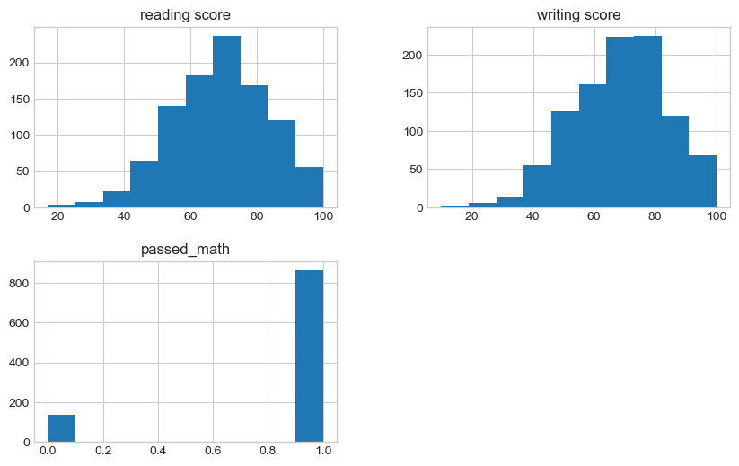

```python
df.hist(figsize=(10,6))
plt.show()
```

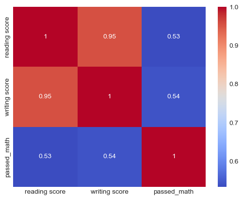

```python
sns.heatmap(df.corr(numeric_only=True), annot=True, cmap="coolwarm")
plt.show()
```

```python
df_processed = preprocess_dataset(df, target_col="passed_math")

df_processed.head()
```

```
Se encontraron filas redundantes (duplicados exactos). Eliminando la primera instancia de cada grupo...
No se encontraron valores perdidos.
Aplicando Label Encoding a las columnas categóricas: ['gender', 'race/ethnicity', 'parental level of education', 'lunch', 'test preparation course']
Dataset preprocesado correctamente.
```

|  | gender | race/ethnicity | parental level of education | lunch | test preparation course | reading score | writing score | passed_math |
| --- | --- | --- | --- | --- | --- | --- | --- | --- |
| 0 | 0 | 1 | 1 | 1 | 1 | 72 | 74 | 1 |
| 1 | 0 | 2 | 4 | 1 | 0 | 90 | 88 | 1 |
| 2 | 0 | 1 | 3 | 1 | 1 | 95 | 93 | 1 |
| 3 | 1 | 0 | 0 | 0 | 1 | 57 | 44 | 0 |
| 4 | 1 | 2 | 4 | 1 | 1 | 78 | 75 | 1 |

```python
print(df_processed.shape)
df_processed["passed_math"].value_counts()
```

```
(996, 8)
```

```
passed_math
1    862
0    134
Name: count, dtype: int64
```

## Método de validación

### Stratified hold out

Escogí ese ya que mis clases estan desbalanceadas y es fácil de implementar

```python
X = df_processed.drop("passed_math", axis=1)
y = df_processed["passed_math"]

X_train, X_test, y_train, y_test = train_test_split(
    X,
    y,
    test_size=0.2,
    random_state=42,
    stratify=y
)
```

## Feature Selecion (ANOVA)

- Anova mide qué tan diferente es la media entre clases comparada con la variación dentro de cada clase.

Ejemplo, ANOVA analiza cada variable por separado así:

```
reading_score
   media cuando passed_math = 0
   vs
   media cuando passed_math = 1
```

```python
from sklearn.feature_selection import f_classif

f_scores, p_values = f_classif(X_train, y_train)

anova_results = pd.DataFrame({
    "feature": X_train.columns,
    "f_score": f_scores,
    "p_value": p_values
})

selected_features = anova_results[anova_results["p_value"] < 0.05]["feature"]

print("Features seleccionadas:")
print(list(selected_features))
```

```
Features seleccionadas:
['gender', 'race/ethnicity', 'lunch', 'test preparation course', 'reading score', 'writing score']
```

```python
X_train_selected = X_train[selected_features]
X_test_selected = X_test[selected_features]
```

```python
anova_results = anova_results.sort_values("f_score", ascending=False)

print("Tabla ANOVA:")
display(anova_results)
```

```
Tabla ANOVA:
```

|  | feature | f_score | p_value |
| --- | --- | --- | --- |
| 6 | writing score | 324.586799 | 4.227763e-61 |
| 5 | reading score | 311.295599 | 4.937006e-59 |
| 3 | lunch | 84.455666 | 3.368308e-19 |
| 4 | test preparation course | 10.402217 | 1.310152e-03 |
| 1 | race/ethnicity | 7.458052 | 6.455398e-03 |
| 0 | gender | 6.421188 | 1.146785e-02 |
| 2 | parental level of education | 0.775457 | 3.788007e-01 |

```python
selected_features = anova_results[anova_results["p_value"] < 0.05]["feature"]
print("Características seleccionadas:")
print(list(selected_features))

removed_features = anova_results[anova_results["p_value"] >= 0.05]["feature"]
print("\nCaracterísticas eliminadas:")
print(list(removed_features))

print("="*50)
print("Selección de características con ANOVA")
print("="*50)

print("Características originales:", len(X_train.columns))
print("Características seleccionadas:", len(selected_features))
print("Características eliminadas:", len(removed_features))
```

```
Características seleccionadas:
['writing score', 'reading score', 'lunch', 'test preparation course', 'race/ethnicity', 'gender']

Características eliminadas:
['parental level of education']
==================================================
Selección de características con ANOVA
==================================================
Características originales: 7
Características seleccionadas: 6
Características eliminadas: 1
```

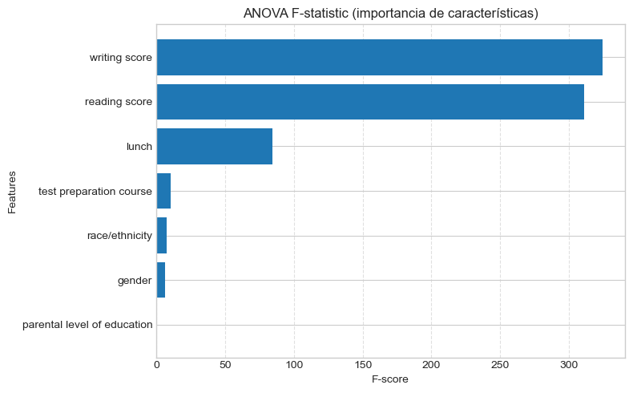

```python
# Gráfico de F-score =  capacidad de separar las clases
import matplotlib.pyplot as plt

# Ordenar por importancia
anova_sorted = anova_results.sort_values("f_score", ascending=True)

plt.figure(figsize=(8,5))

plt.barh(
    anova_sorted["feature"],
    anova_sorted["f_score"],
)

plt.title("ANOVA F-statistic (importancia de características)")
plt.xlabel("F-score")
plt.ylabel("Features")

plt.grid(axis="x", linestyle="--", alpha=0.6)

plt.tight_layout()
plt.show()
```

*El test ANOVA muestra que las variables* *writing score y reading** score presentan los valores F más altos, indicando que son las características con mayor capacidad para diferenciar entre estudiantes que aprueban o no matemáticas. Esto sugiere una fuerte relación entre el desempeño en matemáticas y las habilidades de lectura y escritura*

## Calcular IR (en TRAIN)

```python
ir, class_counts = calculate_imbalance_ratio(y_train)

print("Distribución de clases:", class_counts)
print("Imbalance Ratio:", ir)
# Con IR > 1.5 desbalance
```

```
Distribución de clases: {0: 107, 1: 689}
Imbalance Ratio: 6.4392523364485985
```

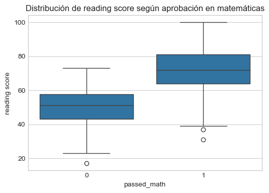

```python
plt.figure(figsize=(6,4))

sns.boxplot(
    x="passed_math",
    y="reading score",
    data=df_processed
)

plt.title("Distribución de reading score según aprobación en matemáticas")
plt.show()
```

*Estudiantes que no pasaron matemáticas mediana ≈ 50, estudiantes que sí ≈ 70, reading_score es mayor cuando passed_math = 1* Esta diferencia entre clases explica los altos valores del estadístico F obtenidos en el test ANOVA.

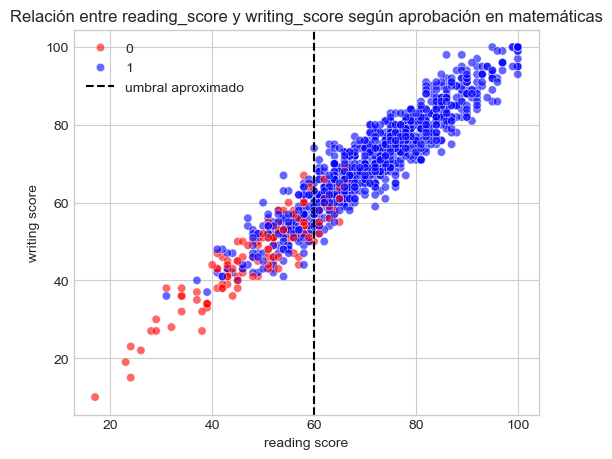

```python
plt.figure(figsize=(6,5))

sns.scatterplot(
    x="reading score",
    y="writing score",
    hue="passed_math",
    data=df_processed,
    palette=["red","blue"],
    alpha=0.6
)

plt.axvline(60, color="black", linestyle="--", label="umbral aproximado")

plt.title("Relación entre reading_score y writing_score según aprobación en matemáticas")
plt.legend()
plt.show()
```

*Las clases se separan bastante bien, siendo variables utiles para clasificar, reading_score y writing_score están casi perfectamente correlacionados*

## SMOTE

```
Distribución en entrenamiento (antes de SMOTE):
Counter({1: 689, 0: 107})

Distribución en entrenamiento (después de SMOTE):
Counter({1: 689, 0: 689})
```

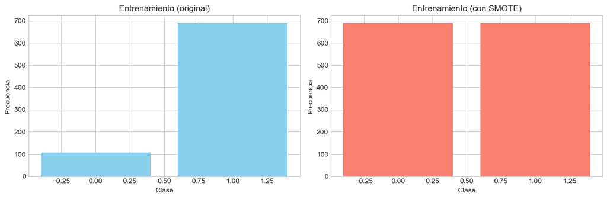

```
Reporte de clasificación (sin SMOTE):
              precision    recall  f1-score   support

           0       0.55      0.63      0.59        27
           1       0.94      0.92      0.93       173

    accuracy                           0.88       200
   macro avg       0.74      0.77      0.76       200
weighted avg       0.89      0.88      0.88       200


Reporte de clasificación (con SMOTE):
              precision    recall  f1-score   support

           0       0.56      0.74      0.63        27
           1       0.96      0.91      0.93       173

    accuracy                           0.89       200
   macro avg       0.76      0.82      0.78       200
weighted avg       0.90      0.89      0.89       200
```

```python
SEMILLA = 666
# Aplicar SMOTE
from SMOTE import plot_class_distribution, aplicar_smote
from collections import Counter
from sklearn.ensemble import RandomForestClassifier
from sklearn.metrics import classification_report

print("Distribución en entrenamiento (antes de SMOTE):")
print(Counter(y_train))
print()

# Aplicar SMOTE
X_train_res, y_train_res = aplicar_smote(X_train_selected, y_train)

print("Distribución en entrenamiento (después de SMOTE):")
print(Counter(y_train_res))
print()

# Mostrar gráfico comparativo
plot_class_distribution(
    y_train,
    y_train_res,
    title_before='Entrenamiento (original)',
    title_after='Entrenamiento (con SMOTE)'
)

from sklearn.ensemble import RandomForestClassifier
from sklearn.metrics import classification_report

# Modelo sin balanceo como ejemplo para demostrar efecto SMOTE
clf_orig = RandomForestClassifier(random_state=SEMILLA, n_jobs=-1)

clf_orig.fit(X_train_selected, y_train)

y_pred_orig = clf_orig.predict(X_test_selected)

print("Reporte de clasificación (sin SMOTE):")
print(classification_report(y_test, y_pred_orig))

# Modelo con SMOTE
clf_smote = RandomForestClassifier(random_state=SEMILLA)

clf_smote.fit(X_train_res, y_train_res)

y_pred_smote = clf_smote.predict(X_test_selected)

print("\nReporte de clasificación (con SMOTE):")
print(classification_report(y_test, y_pred_smote))
```

*Se puede observar que el accuracy no cambió mucho, lo cual es normal, pero el recall de la clase minoritaria paro de 0.63 a 0.74, lo que indica que el modelo ahora detecta mejor los casos de la clase minoritaria*

## Entrenamiento sin SMOTE

```python
# Definir modelos a evaluar con scikit-learn
models = {
    "KNN (k=1)": Pipeline([
        ("scaler", StandardScaler()),
        ("clf", KNeighborsClassifier(n_neighbors=1))
    ]),
    "KNN (k=3)": Pipeline([
        ("scaler", StandardScaler()),
        ("clf", KNeighborsClassifier(n_neighbors=3))
    ]),
    "KNN (k=5)": Pipeline([
        ("scaler", StandardScaler()),
        ("clf", KNeighborsClassifier(n_neighbors=5))
    ]),
    "Regresión Logística": Pipeline([
        ("scaler", StandardScaler()),
        ("clf", LogisticRegression(max_iter=1000))
    ]),
    "J48 (Entropy Tree)": DecisionTreeClassifier(
        criterion="entropy",
        random_state=SEMILLA
    ),
    "Random Forest": RandomForestClassifier(
        n_estimators=300, # Número de árboles
        random_state=SEMILLA
    ),
    "SVM (RBF)": Pipeline([
        ("scaler", StandardScaler()),
        ("clf", SVC(kernel="rbf", probability=True, random_state=SEMILLA))
    ]),
    "MLP": Pipeline([
        ("scaler", StandardScaler()),
        ("clf", MLPClassifier(
            hidden_layer_sizes=(32,16),
            max_iter=3000,
            random_state=SEMILLA
        ))
    ]),
    "Naive Bayes": GaussianNB()
}
```

```python
results_no_smote = []
roc_data_no_smote = []
conf_matrices_no_smote = {}

for name, model in models.items():

    print("\n" + "="*60)
    print("Entrenando modelo:", name)
    print("="*60)

    # entrenamiento
    model.fit(X_train_selected, y_train)

    # predicción
    y_pred = model.predict(X_test_selected)

    # ROC scores
    if hasattr(model, "predict_proba"):
        y_scores = model.predict_proba(X_test_selected)[:,1]
    else:
        y_scores = model.decision_function(X_test_selected)

    fpr, tpr, _ = roc_curve(y_test, y_scores)
    roc_auc = auc(fpr, tpr)

    roc_data_no_smote.append((name, fpr, tpr, roc_auc))

    # matriz de confusión
    TP, TN, FP, FN = calculate_confusion_matrix(
        y_test,
        y_pred,
        positive_class=1,
        negative_class=0
    )

    conf_matrices_no_smote[name] = [[TP, FN],
                                   [FP, TN]]

    # métricas
    metrics = calculate_metrics(TP, TN, FP, FN)

    metrics["model"] = name
    metrics["roc_auc"] = roc_auc

    results_no_smote.append(metrics)

    print(f"AUC: {roc_auc:.3f}")
    print(f"Accuracy: {metrics['accuracy']:.3f}")
    print(f"F1-score: {metrics['f1_score']:.3f}")
    print(f"Recall: {metrics['sensitivity']:.3f}")
```

```
============================================================
Entrenando modelo: KNN (k=1)
============================================================
AUC: 0.790
Accuracy: 0.880
F1-score: 0.929
Recall: 0.913

============================================================
Entrenando modelo: KNN (k=3)
============================================================
AUC: 0.855
Accuracy: 0.890
F1-score: 0.936
Recall: 0.925

============================================================
Entrenando modelo: KNN (k=5)
============================================================
AUC: 0.889
Accuracy: 0.880
F1-score: 0.930
Recall: 0.925

============================================================
Entrenando modelo: Regresión Logística
============================================================
AUC: 0.957
Accuracy: 0.915
F1-score: 0.951
Recall: 0.960

============================================================
Entrenando modelo: J48 (Entropy Tree)
============================================================
AUC: 0.773
Accuracy: 0.875
F1-score: 0.927
Recall: 0.913

```

[output cut: 16 more lines]

```
============================================================
Entrenando modelo: MLP
============================================================
AUC: 0.948
Accuracy: 0.895
F1-score: 0.938
Recall: 0.925

============================================================
Entrenando modelo: Naive Bayes
============================================================
AUC: 0.946
Accuracy: 0.885
F1-score: 0.932
Recall: 0.908
```

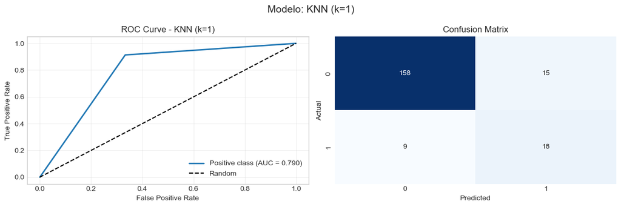

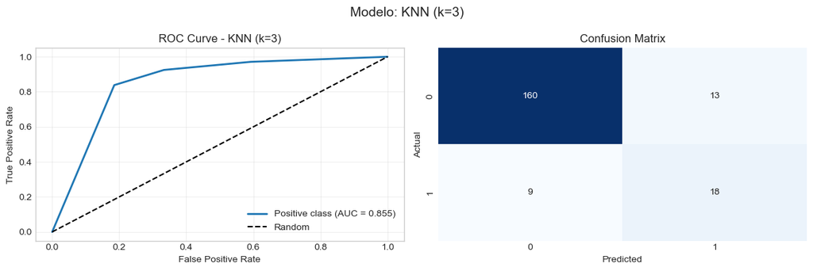

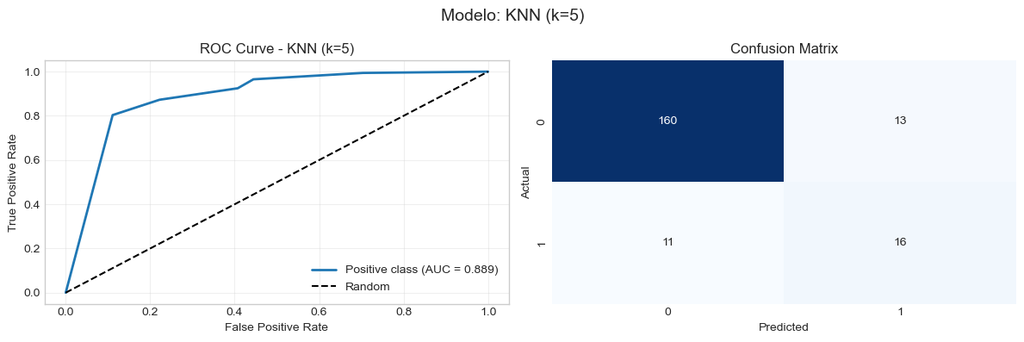

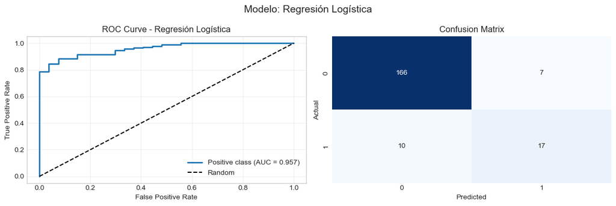

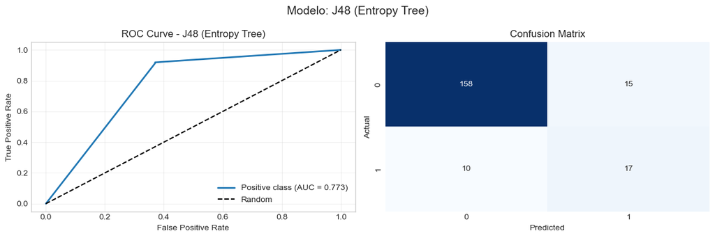

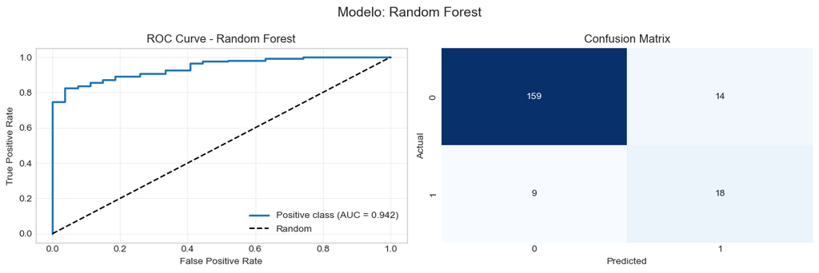

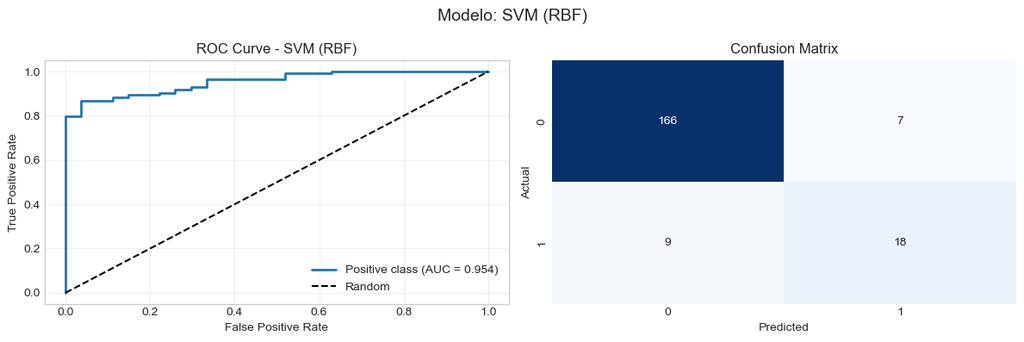

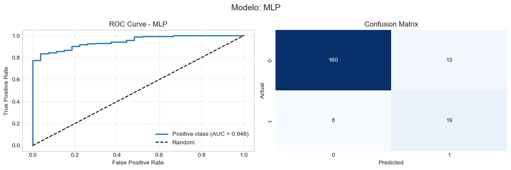

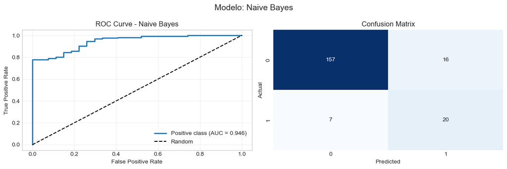

```python
import seaborn as sns

for name, fpr, tpr, roc_auc in roc_data_no_smote:

    cm = conf_matrices_no_smote[name]

    fig, axes = plt.subplots(1,2, figsize=(12,4))

    # ROC
    axes[0].plot(
        fpr,
        tpr,
        linewidth=2,
        label=f"Positive class (AUC = {roc_auc:.3f})"
    )

    axes[0].plot([0,1],[0,1],'k--', label="Random")
    axes[0].set_title(f"ROC Curve - {name}")
    axes[0].set_xlabel("False Positive Rate")
    axes[0].set_ylabel("True Positive Rate")
    axes[0].legend()
    axes[0].grid(alpha=0.3)

    # Confusion matrix
    sns.heatmap(
        cm,
        annot=True,
        fmt="d",
        cmap="Blues",
        ax=axes[1],
        cbar=False
    )

    axes[1].set_title("Confusion Matrix")
    axes[1].set_xlabel("Predicted")
    axes[1].set_ylabel("Actual")

    plt.suptitle(f"Modelo: {name}", fontsize=14)

    plt.tight_layout()
    plt.show()
```

## Métricas de desempeño sin SMOTE

```python
# Métricas de desempeño, resumen
df_results_no_smote = pd.DataFrame(results_no_smote)
df_results_no_smote = df_results_no_smote.set_index("model")

print(df_results_no_smote.sort_values(by="accuracy", ascending=False))
```

```
                     accuracy  error_rate  sensitivity  specificity  \
model
SVM (RBF)               0.920       0.080     0.959538     0.666667
Regresión Logística     0.915       0.085     0.959538     0.629630
MLP                     0.895       0.105     0.924855     0.703704
KNN (k=3)               0.890       0.110     0.924855     0.666667
Random Forest           0.885       0.115     0.919075     0.666667
Naive Bayes             0.885       0.115     0.907514     0.740741
KNN (k=1)               0.880       0.120     0.913295     0.666667
KNN (k=5)               0.880       0.120     0.924855     0.592593
J48 (Entropy Tree)      0.875       0.125     0.913295     0.629630

                     balanced_accuracy  precision       mcc  f1_score  \
model
SVM (RBF)                     0.813102   0.948571  0.647041  0.954023
Regresión Logística           0.794584   0.943182  0.619557  0.951289
MLP                           0.814280   0.952381  0.585897  0.938416
KNN (k=3)                     0.795761   0.946746  0.558537  0.935673
Random Forest                 0.792871   0.946429  0.545986  0.932551
Naive Bayes                   0.824128   0.957317  0.576604  0.931751
KNN (k=1)                     0.789981   0.946108  0.533936  0.929412
KNN (k=5)                     0.758724   0.935673  0.502198  0.930233
J48 (Entropy Tree)            0.771462   0.940476  0.506075  0.926686

                      roc_auc
model
SVM (RBF)            0.954399
Regresión Logística  0.957397
MLP                  0.947977
KNN (k=3)            0.855491
Random Forest        0.941982
Naive Bayes          0.946050
KNN (k=1)            0.789981
KNN (k=5)            0.888675
J48 (Entropy Tree)   0.773282
```

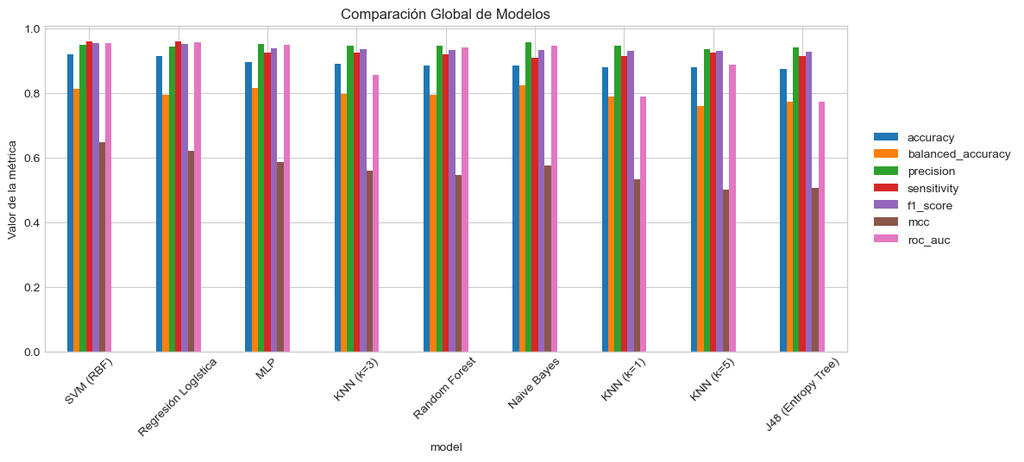

```python
# Gráfica comparativa global
metrics_to_plot = [
    "accuracy",
    "balanced_accuracy",
    "precision",
    "sensitivity",
    "f1_score",
    "mcc",
    "roc_auc"
]

plt.figure(figsize=(12,6))

ax = df_results_no_smote[metrics_to_plot].sort_values(
    by="accuracy",
    ascending=False
).plot(kind="bar", figsize=(12,6))

ax.set_title("Comparación Global de Modelos")
ax.set_ylabel("Valor de la métrica")
plt.xticks(rotation=45)

ax.legend(
    loc="center left",
    bbox_to_anchor=(1.02, 0.5),
)

plt.subplots_adjust(bottom=0.25)  # ← esto crea más espacio
plt.show()
```

```python
df_test_results = X_test.copy()

df_test_results["real"] = y_test.values
df_test_results["predicho"] = y_pred

df_test_results.head()
```

|  | gender | race/ethnicity | parental level of education | lunch | test preparation course | reading score | writing score | real | predicho |
| --- | --- | --- | --- | --- | --- | --- | --- | --- | --- |
| 610 | 1 | 3 | 4 | 0 | 0 | 60 | 63 | 1 | 1 |
| 787 | 0 | 1 | 4 | 1 | 1 | 38 | 32 | 0 | 0 |
| 282 | 0 | 3 | 1 | 0 | 1 | 79 | 84 | 1 | 1 |
| 927 | 0 | 3 | 2 | 0 | 0 | 61 | 71 | 1 | 1 |
| 242 | 0 | 3 | 2 | 1 | 1 | 52 | 55 | 1 | 1 |

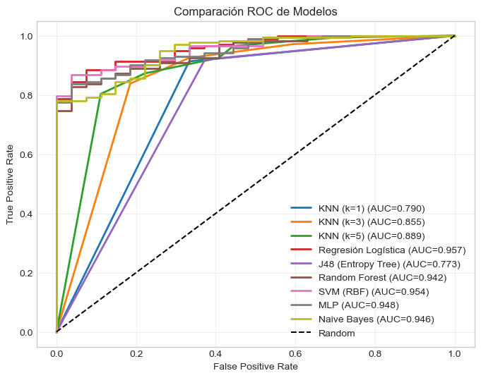

```python
# ROC de todos los modelos
plt.figure(figsize=(8,6))

for name, fpr, tpr, roc_auc in roc_data_no_smote:
    plt.plot(fpr, tpr, linewidth=2, label=f"{name} (AUC={roc_auc:.3f})")

plt.plot([0,1],[0,1],'k--', label="Random")

plt.xlabel("False Positive Rate")
plt.ylabel("True Positive Rate")
plt.title("Comparación ROC de Modelos")

plt.legend(loc="lower right")
plt.grid(alpha=0.3)

plt.show()
```

## Entrenamiento con SMOTE

*SMOTE solo balancea el entrenamiento*

```python
# Definir modelos a evaluar con scikit-learn
models = {
    "KNN (k=1)": Pipeline([
        ("scaler", StandardScaler()),
        ("clf", KNeighborsClassifier(n_neighbors=1))
    ]),
    "KNN (k=3)": Pipeline([
        ("scaler", StandardScaler()),
        ("clf", KNeighborsClassifier(n_neighbors=3))
    ]),
    "KNN (k=5)": Pipeline([
        ("scaler", StandardScaler()),
        ("clf", KNeighborsClassifier(n_neighbors=5))
    ]),
    "Regresión Logística": Pipeline([
        ("scaler", StandardScaler()),
        ("clf", LogisticRegression(max_iter=1000))
    ]),
    "J48 (Entropy Tree)": DecisionTreeClassifier(
        criterion="entropy",
        random_state=SEMILLA
    ),
    "Random Forest": RandomForestClassifier(
        n_estimators=300, # Número de árboles
        random_state=SEMILLA
    ),
    "SVM (RBF)": Pipeline([
        ("scaler", StandardScaler()),
        ("clf", SVC(kernel="rbf", probability=True, random_state=SEMILLA))
    ]),
    "MLP": Pipeline([
        ("scaler", StandardScaler()),
        ("clf", MLPClassifier(
            hidden_layer_sizes=(32,16),
            max_iter=3000,
            random_state=SEMILLA
        ))
    ]),
    "Naive Bayes": GaussianNB()
}
results_smote = []
roc_data_smote = []
conf_matrices = {}

for name, model in models.items():

    print("\n" + "="*60)
    print("Entrenando modelo:", name)
    print("="*60)

    # entrenamiento
    model.fit(X_train_res, y_train_res)


    # predicción
    y_pred = model.predict(X_test_selected)

    # scores ROC
    if hasattr(model, "predict_proba"):
        y_scores = model.predict_proba(X_test_selected)[:,1]
    else:
        y_scores = model.decision_function(X_test_selected)

    fpr, tpr, _ = roc_curve(y_test, y_scores)
    roc_auc = auc(fpr, tpr)

    roc_data_smote.append((name, fpr, tpr, roc_auc))

    TP, TN, FP, FN = calculate_confusion_matrix(
    y_test,
    y_pred,
    positive_class=1,
    negative_class=0
    )

    conf_matrices[name] = [[TP, FN],
                          [FP, TN]]

    # Métricas
    metrics = calculate_metrics(TP,TN,FP,FN)

    metrics["model"] = name
    metrics["roc_auc"] = roc_auc

    results_smote.append(metrics)

    # Resultados
    print(f"AUC: {roc_auc:.3f}")
    print(f"Accuracy (test): {metrics['accuracy']:.3f}")
    print(f"F1-score (test): {metrics['f1_score']:.3f}")
    print(f"Recall / Sensitivity (test): {metrics['sensitivity']:.3f}")
```

```
============================================================
Entrenando modelo: KNN (k=1)
============================================================
AUC: 0.807
Accuracy (test): 0.855
F1-score (test): 0.912
Recall / Sensitivity (test): 0.873

============================================================
Entrenando modelo: KNN (k=3)
============================================================
AUC: 0.845
Accuracy (test): 0.855
F1-score (test): 0.912
Recall / Sensitivity (test): 0.867

============================================================
Entrenando modelo: KNN (k=5)
============================================================
AUC: 0.874
Accuracy (test): 0.860
F1-score (test): 0.915
Recall / Sensitivity (test): 0.873

============================================================
Entrenando modelo: Regresión Logística
============================================================
AUC: 0.954
Accuracy (test): 0.860
F1-score (test): 0.916
Recall / Sensitivity (test): 0.879

============================================================
Entrenando modelo: J48 (Entropy Tree)
============================================================
AUC: 0.839
Accuracy (test): 0.880
F1-score (test): 0.928
Recall / Sensitivity (test): 0.896

```

[output cut: 16 more lines]

```
============================================================
Entrenando modelo: MLP
============================================================
AUC: 0.940
Accuracy (test): 0.885
F1-score (test): 0.932
Recall / Sensitivity (test): 0.908

============================================================
Entrenando modelo: Naive Bayes
============================================================
AUC: 0.934
Accuracy (test): 0.865
F1-score (test): 0.918
Recall / Sensitivity (test): 0.873
```

## Visualización

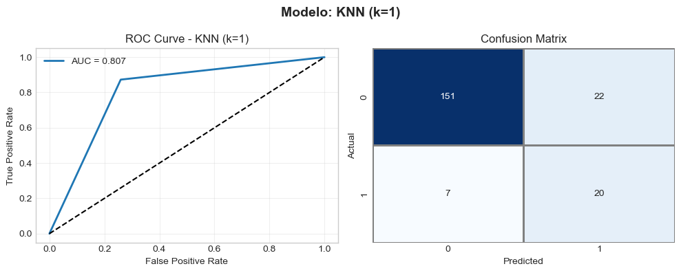

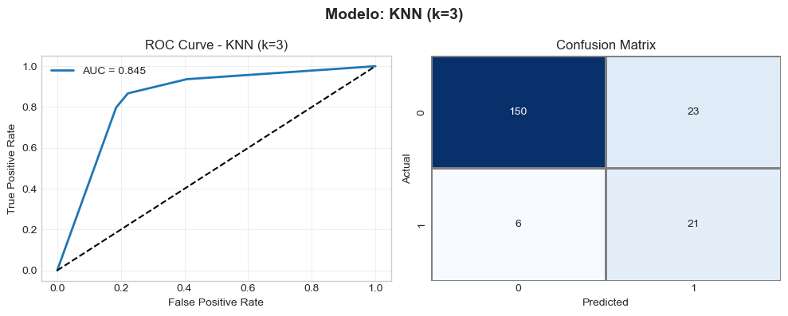

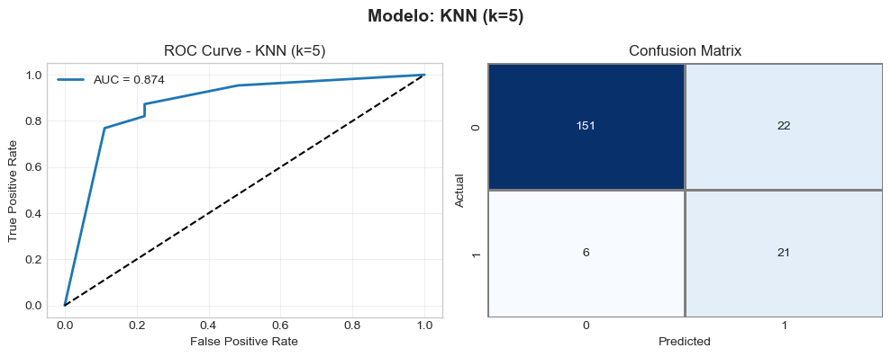

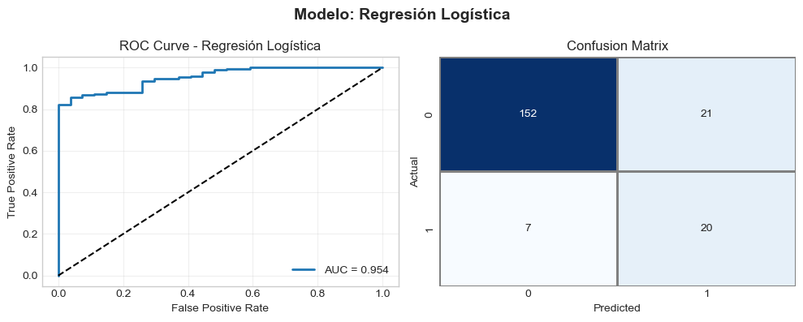

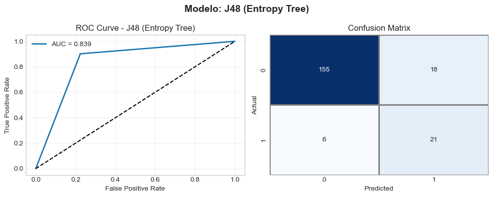

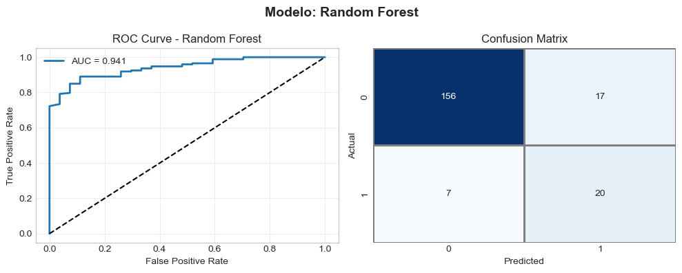

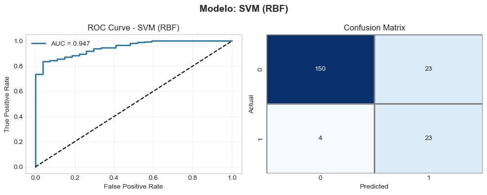

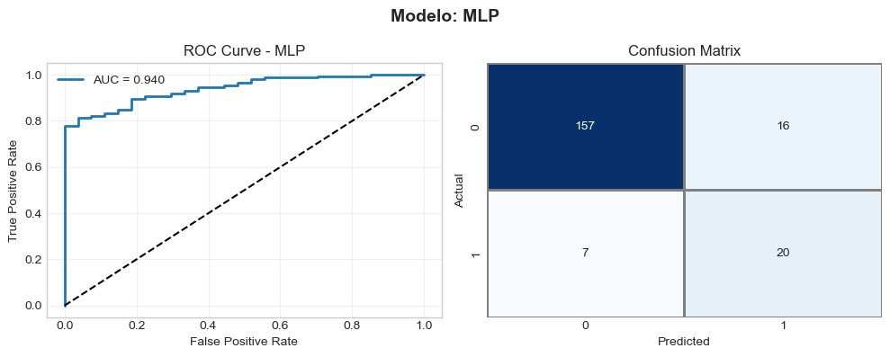

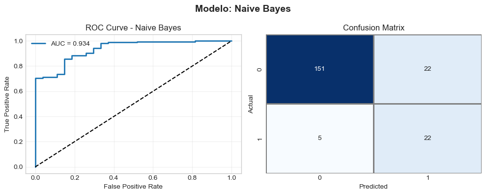

```python
import seaborn as sns

for name, fpr, tpr, roc_auc in roc_data_smote:

    cm = conf_matrices[name]
    plt.style.use("seaborn-v0_8-whitegrid")
    fig, axes = plt.subplots(1,2, figsize=(10,4))
    fig.suptitle(f"Modelo: {name}", fontsize=14, fontweight="bold")
    # ROC
    axes[0].plot(fpr, tpr, linewidth=2, label=f"AUC = {roc_auc:.3f}")
    axes[0].plot([0,1],[0,1],'k--')
    axes[0].set_title(f"ROC Curve - {name}")
    axes[0].set_xlabel("False Positive Rate")
    axes[0].set_ylabel("True Positive Rate")
    axes[0].legend()
    axes[0].grid(alpha=0.3)

    # Confusion matrix
    sns.heatmap(
        cm,
        annot=True,
        fmt="d",
        cmap="Blues",
        cbar=False,
        ax=axes[1],
        linewidths=1,
        linecolor="gray"
    )

    axes[1].set_title("Confusion Matrix")
    axes[1].set_xlabel("Predicted")
    axes[1].set_ylabel("Actual")

    plt.tight_layout()
    plt.show()
```

## Métricas de desempeño

```python
df_results_smote = pd.DataFrame(results_smote)
df_results_smote = df_results_smote.set_index("model")

print(df_results_smote.sort_values(by="accuracy", ascending=False))
```

```
                     accuracy  error_rate  sensitivity  specificity  \
model
MLP                     0.885       0.115     0.907514     0.740741
J48 (Entropy Tree)      0.880       0.120     0.895954     0.777778
Random Forest           0.880       0.120     0.901734     0.740741
SVM (RBF)               0.865       0.135     0.867052     0.851852
Naive Bayes             0.865       0.135     0.872832     0.814815
KNN (k=5)               0.860       0.140     0.872832     0.777778
Regresión Logística     0.860       0.140     0.878613     0.740741
KNN (k=1)               0.855       0.145     0.872832     0.740741
KNN (k=3)               0.855       0.145     0.867052     0.777778

                     balanced_accuracy  precision       mcc  f1_score  \
model
MLP                           0.824128   0.957317  0.576604  0.931751
J48 (Entropy Tree)            0.836866   0.962733  0.581094  0.928144
Random Forest                 0.821237   0.957055  0.565414  0.928571
SVM (RBF)                     0.859452   0.974026  0.583763  0.917431
Naive Bayes                   0.843824   0.967949  0.567260  0.917933
KNN (k=5)                     0.825305   0.961783  0.541180  0.915152
Regresión Logística           0.809677   0.955975  0.524268  0.915663
KNN (k=1)                     0.806787   0.955696  0.514776  0.912387
KNN (k=3)                     0.822415   0.961538  0.531938  0.911854

                      roc_auc
model
MLP                  0.940270
J48 (Entropy Tree)   0.839114
Random Forest        0.941233
SVM (RBF)            0.947121
Naive Bayes          0.934061
KNN (k=5)            0.874331
Regresión Logística  0.953757
KNN (k=1)            0.806787
KNN (k=3)            0.845429
```

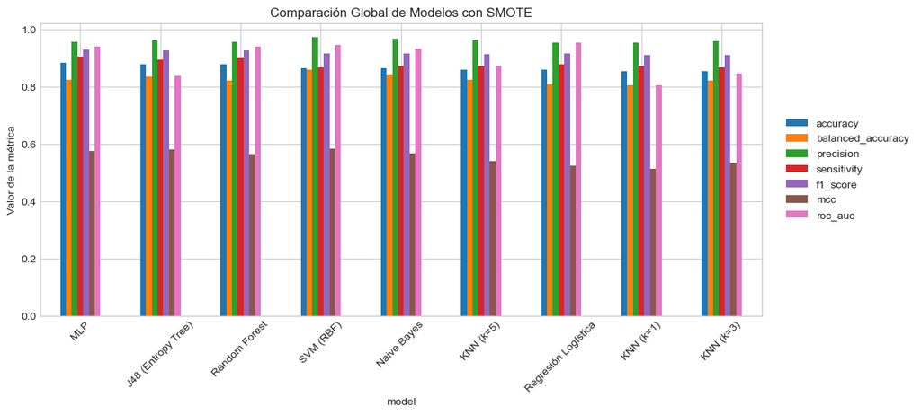

```python
# Gráfica comparativa global
metrics_to_plot = [
    "accuracy",
    "balanced_accuracy",
    "precision",
    "sensitivity",
    "f1_score",
    "mcc",
    "roc_auc"
]

plt.figure(figsize=(12,6))

ax = df_results_smote[metrics_to_plot].sort_values(
    by="accuracy",
    ascending=False
).plot(kind="bar", figsize=(12,6))

ax.set_title("Comparación Global de Modelos con SMOTE")
ax.set_ylabel("Valor de la métrica")
plt.xticks(rotation=45)

ax.legend(
    loc="center left",
    bbox_to_anchor=(1.02, 0.5),
)

plt.subplots_adjust(bottom=0.25)  # ← esto crea más espacio
plt.show()
```

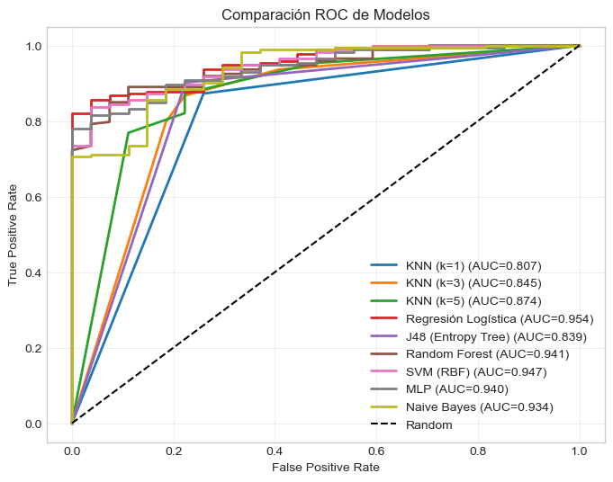

```python
# ROC de todos los modelos
plt.figure(figsize=(8,6))

for name, fpr, tpr, roc_auc in roc_data_smote:
    plt.plot(fpr, tpr, linewidth=2, label=f"{name} (AUC={roc_auc:.3f})")

plt.plot([0,1],[0,1],'k--', label="Random")

plt.xlabel("False Positive Rate")
plt.ylabel("True Positive Rate")
plt.title("Comparación ROC de Modelos")

plt.legend(loc="lower right")
plt.grid(alpha=0.3)

plt.show()
```

## COMPARACIÓN

```python
# Métricas de desempeño, resumen
model_names = list(models.keys())

df_no_smote["model"] = model_names
df_smote["model"] = model_names

df_no_smote = df_no_smote.set_index("model")
df_smote = df_smote.set_index("model")
display(Markdown("## Métricas de desempeño de los modelos SIN SMOTE"))
display(df_no_smote)
display(Markdown("## Métricas de desempeño de los modelos CON SMOTE"))
display(df_smote)
```

Métricas de desempeño de los modelos SIN SMOTE

| model | accuracy | error_rate | sensitivity | specificity | balanced_accuracy | precision | mcc | f1_score | roc_auc |
| --- | --- | --- | --- | --- | --- | --- | --- | --- | --- |
| KNN (k=1) | 0.880 | 0.120 | 0.913295 | 0.666667 | 0.789981 | 0.946108 | 0.533936 | 0.929412 | 0.789981 |
| KNN (k=3) | 0.890 | 0.110 | 0.924855 | 0.666667 | 0.795761 | 0.946746 | 0.558537 | 0.935673 | 0.855491 |
| KNN (k=5) | 0.880 | 0.120 | 0.924855 | 0.592593 | 0.758724 | 0.935673 | 0.502198 | 0.930233 | 0.888675 |
| Regresión Logística | 0.915 | 0.085 | 0.959538 | 0.629630 | 0.794584 | 0.943182 | 0.619557 | 0.951289 | 0.957397 |
| J48 (Entropy Tree) | 0.875 | 0.125 | 0.913295 | 0.629630 | 0.771462 | 0.940476 | 0.506075 | 0.926686 | 0.773282 |
| Random Forest | 0.885 | 0.115 | 0.919075 | 0.666667 | 0.792871 | 0.946429 | 0.545986 | 0.932551 | 0.941982 |
| SVM (RBF) | 0.920 | 0.080 | 0.959538 | 0.666667 | 0.813102 | 0.948571 | 0.647041 | 0.954023 | 0.954399 |
| MLP | 0.895 | 0.105 | 0.924855 | 0.703704 | 0.814280 | 0.952381 | 0.585897 | 0.938416 | 0.947977 |
| Naive Bayes | 0.885 | 0.115 | 0.907514 | 0.740741 | 0.824128 | 0.957317 | 0.576604 | 0.931751 | 0.946050 |

Métricas de desempeño de los modelos CON SMOTE

| model | accuracy | error_rate | sensitivity | specificity | balanced_accuracy | precision | mcc | f1_score | roc_auc |
| --- | --- | --- | --- | --- | --- | --- | --- | --- | --- |
| KNN (k=1) | 0.855 | 0.145 | 0.872832 | 0.740741 | 0.806787 | 0.955696 | 0.514776 | 0.912387 | 0.806787 |
| KNN (k=3) | 0.855 | 0.145 | 0.867052 | 0.777778 | 0.822415 | 0.961538 | 0.531938 | 0.911854 | 0.845429 |
| KNN (k=5) | 0.860 | 0.140 | 0.872832 | 0.777778 | 0.825305 | 0.961783 | 0.541180 | 0.915152 | 0.874331 |
| Regresión Logística | 0.860 | 0.140 | 0.878613 | 0.740741 | 0.809677 | 0.955975 | 0.524268 | 0.915663 | 0.953757 |
| J48 (Entropy Tree) | 0.880 | 0.120 | 0.895954 | 0.777778 | 0.836866 | 0.962733 | 0.581094 | 0.928144 | 0.839114 |
| Random Forest | 0.880 | 0.120 | 0.901734 | 0.740741 | 0.821237 | 0.957055 | 0.565414 | 0.928571 | 0.941233 |
| SVM (RBF) | 0.865 | 0.135 | 0.867052 | 0.851852 | 0.859452 | 0.974026 | 0.583763 | 0.917431 | 0.947121 |
| MLP | 0.885 | 0.115 | 0.907514 | 0.740741 | 0.824128 | 0.957317 | 0.576604 | 0.931751 | 0.940270 |
| Naive Bayes | 0.865 | 0.135 | 0.872832 | 0.814815 | 0.843824 | 0.967949 | 0.567260 | 0.917933 | 0.934061 |

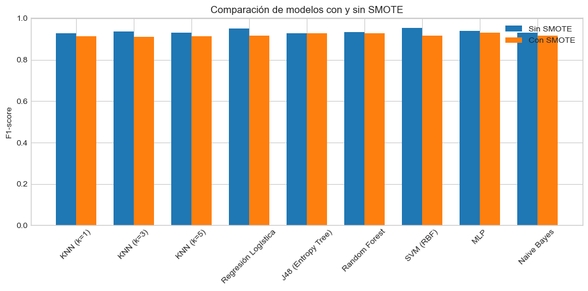

```python
import matplotlib.pyplot as plt
import numpy as np

models = df_no_smote.index

x = np.arange(len(models))
width = 0.35

plt.figure(figsize=(10,5))

plt.bar(x - width/2, df_no_smote["f1_score"], width, label="Sin SMOTE")
plt.bar(x + width/2, df_smote["f1_score"], width, label="Con SMOTE")

plt.xticks(x, models, rotation=45)
plt.ylabel("F1-score")
plt.title("Comparación de modelos con y sin SMOTE")

plt.legend()
plt.tight_layout()
plt.show()
```

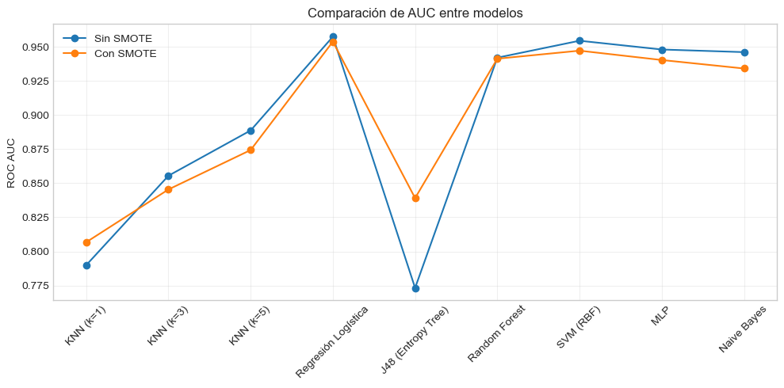

```python
plt.figure(figsize=(10,5))

plt.plot(df_no_smote.index, df_no_smote["roc_auc"], marker="o", label="Sin SMOTE")
plt.plot(df_smote.index, df_smote["roc_auc"], marker="o", label="Con SMOTE")

plt.xticks(rotation=45)
plt.ylabel("ROC AUC")
plt.title("Comparación de AUC entre modelos")

plt.legend()
plt.grid(alpha=0.3)
plt.tight_layout()
plt.show()
```

## Discusión de resultados

### Resultados sin SMOTE

En el conjunto original (sin balanceo) con feature selection de ANOVA, los modelos obtuvieron altos valores de accuracy y AUC, destacando especialmente:

SVM (RBF) con el mejor desempeño general

Regresión Logística y Random Forest también con resultados competitivos

Por ejemplo:

- SVM
- Accuracy ≈ 0.92
- AUC ≈ 0.95
- F1-score ≈ 0.95

Esto indica que el modelo logra separar correctamente las clases en la mayoría de los casos.

Sin embargo, se observa que la specificity es relativamente baja (~0.66) en varios modelos, lo que significa que el modelo no identifica tan bien la clase negativa.

Esto ocurre porque el dataset original estaba desbalanceado, con mayor presencia de una clase.

### Resultados con SMOTE

Después de aplicar SMOTE, el conjunto de entrenamiento se balanceó generando muestras sintéticas de la clase minoritraria. Sin embargo, los resultados mostraron que:

- Accuracy disminuyó ligeramente
- AUC cambió muy poco
- F1-score se mantuvo similar

Pero specifity sí mejoro pues el modelo fallaba bastante al detectar la clase negativa al ser la positiva más frecuente se sesgaba hacia ella. El accuracy disminiyo un poco lo cual es normal porque el modelo se volvio menos sesgado a la clase mayoritaria.

### Comparación con la tarea 1 (sin feature selection)

En la tarea anterior no se aplicó feature selection, por lo que:

- los modelos se entrenaron con todas las variables, ya aplicando ANOVA se elimino una

Al aplicar selección de características (ANOVA):

Se mejora la capacidad de generalización del modelo

Esto puede explicar por qué algunas métricas cambiaron mejorando.

## Conclusión

La aplicación de SMOTE permitió mejorar significativamente la specificity de los modelos, lo que indica una mejor capacidad para identificar correctamente la clase negativa (estudiantes que no aprueban matemáticas).

Sin embargo, esta mejora vino acompañada de una ligera disminución en el accuracy global, lo cual es esperado al reducir el sesgo del modelo hacia la clase mayoritaria.

En general, SMOTE contribuyó a un comportamiento más equilibrado del clasificador, aunque el rendimiento global de los modelos ya era alto incluso sin el balanceo.